# FIFA 19 Data Exploration

[figure not shown]

## Investigation Overview

In this investigation, i wanted to look at factors that affects a players value and also factors that affects a players performance.

## Dataset Overview

This is FIFA 19 dataset and originally, the dataset contains 18207 observation and 88 columns. The dataset set had some missing values which i cleaned and i formed a new data frame for the columns that would be of interest in my analysis. After wrangling, my new dataset had 16643 observations and 17 columns.

**Features of interest**:

- Age
- Nationality
- Club
- Release Clause
- Wage
- Value
- Preferred Foot
- Position
- Weight
- Finishing
- Dribbling
- BallControl
- Stamina
- Jumping
- GKReflexes
- Body Type

### Descriptive statistic observation

- The minimum age of a player is 16yrs and 75% of players are below 29 yrs of age.
- The maximum weight of a player is 243lbs.
- 50% of players have stamina rating of 66.

### What is the Age distribution of players?

- We have a right skewed distribution and majority of players are in their 20's.

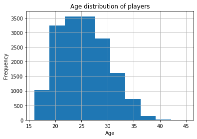

### Top 10 most player Nationality?

- Most players as we can see are from England which could also play a role to why the most populated clubs are England clubs.

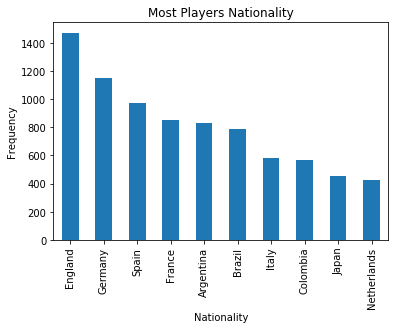

### Lets look at most preferred foot by players

- As we can see, most of the players are right footed and this is also true for the real world.

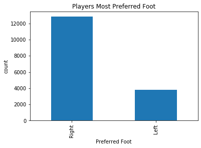

### Correlation between BallControl and Finishing

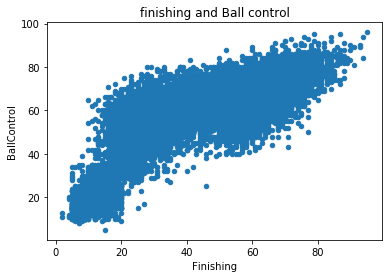

### What club has most player wage?

- Real Madrid a spanish club is the club with most wage.

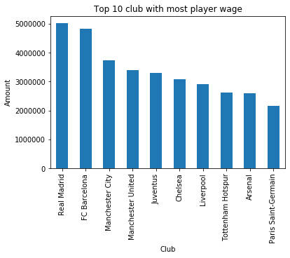

### Preferred fot vs Value

- Left footed players as we have seen have more value when comapared to right footed players.

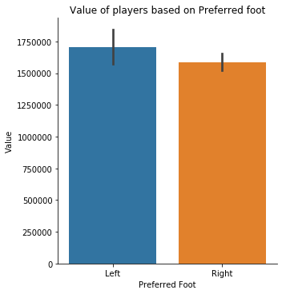

### Players Body Type, Value and Preferred foot

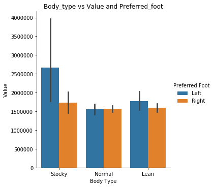